# P1) Model-Building vs. Historical Simulation

## I. Portfolio Construction

```python
!pip install arch -q
```

```
   ━━━━━━━━━━━━━━━━━━━━━━━━━━━━━━━━━━━━━━━━ 985.3/985.3 kB 39.8 MB/s eta 0:00:00
```

```python
import numpy as np
import pandas as pd
import yfinance as yf
import matplotlib.pyplot as plt
import seaborn as sns
from scipy.stats import norm, t, jarque_bera

# Define assets from diverse sectors
assets = [
    'AAPL',    # Technology (Apple)
    'JPM',     # Financial (JPMorgan)
    'XOM',     # Energy (ExxonMobil)
    'WMT'      # Consumer Staples (Walmart)
]

# Fetch 1 year of daily price data (2024-2025)
data = yf.download(assets, start='2024-01-01', end='2025-01-01', auto_adjust=False)['Adj Close']

# Generate random weights summing to 100%
np.random.seed(42)
weights = np.random.random(len(assets))
weights /= weights.sum()

# Calculate daily returns
asset_returns = data.pct_change().dropna()
portfolio_returns = (asset_returns * weights).sum(axis=1)

print("Portfolio Weights:")
for asset, w in zip(assets, weights):
    print(f"{asset}: {w:.2%}")
```

```
[*********************100%***********************]  4 of 4 completed
```

```
Portfolio Weights:
AAPL: 14.10%
JPM: 35.80%
XOM: 27.56%
WMT: 22.54%
```

## II. Normality Assessment

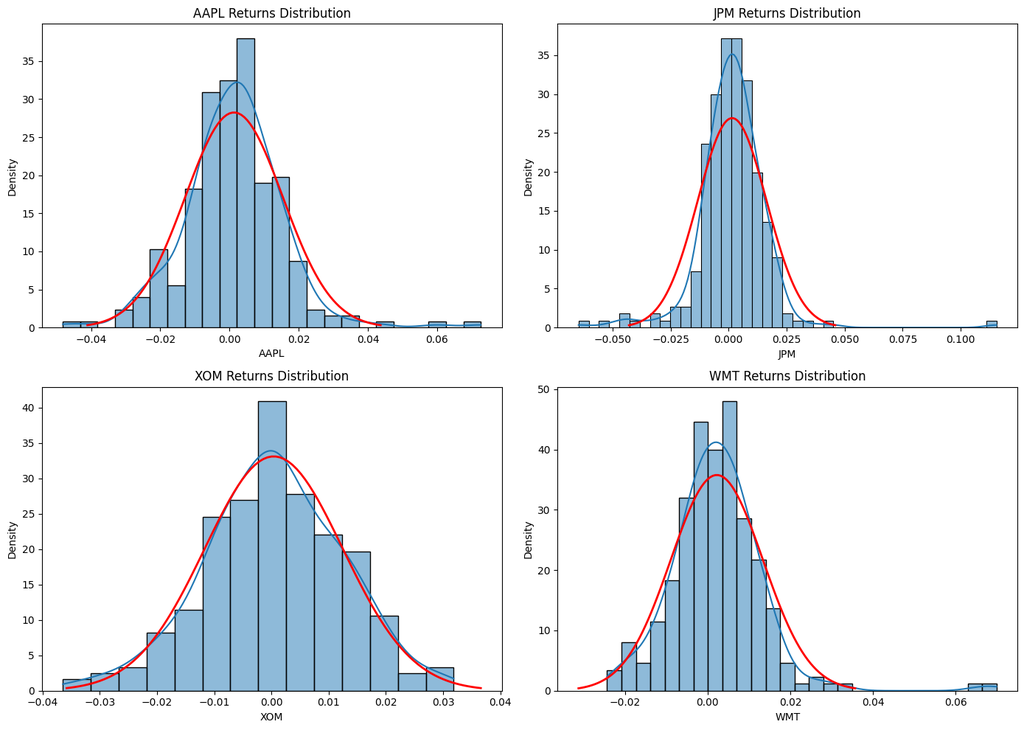

```
Jarque-Bera Test Results:
AAPL: Stat=149.60, p=0.0000
JPM: Stat=2561.75, p=0.0000
XOM: Stat=0.88, p=0.6445
WMT: Stat=852.63, p=0.0000
Portfolio: Stat=174.31, p=0.0000
```

```python
# Plot return distributions
fig, axes = plt.subplots(2, 2, figsize=(14, 10))
axes = axes.flatten()

for i, asset in enumerate(assets):
    sns.histplot(asset_returns[asset], kde=True, ax=axes[i], stat='density')
    axes[i].set_title(f"{asset} Returns Distribution")
    # Overlay normal distribution
    mu, std = asset_returns[asset].mean(), asset_returns[asset].std()
    x = np.linspace(mu - 3*std, mu + 3*std, 100)
    axes[i].plot(x, norm.pdf(x, mu, std), 'r-', lw=2)

plt.tight_layout()
plt.show()

# Jarque-Bera test for normality (Bonus)
jb_results = {}
for asset in assets:
    jb_stat, p_value = jarque_bera(asset_returns[asset])
    jb_results[asset] = {"Statistic": jb_stat, "p-value": p_value}

jb_port = jarque_bera(portfolio_returns)
jb_results["Portfolio"] = {"Statistic": jb_port[0], "p-value": jb_port[1]}

print("Jarque-Bera Test Results:")
for key, val in jb_results.items():
    print(f"{key}: Stat={val['Statistic']:.2f}, p={val['p-value']:.4f}")
```

## III. Parametric VaR Calculation

```python
# III. Parametric VaR Calculation (Corrected)

# Without correlations (assume independence)
# Portfolio variance = Σ(w_i^2 * σ_i^2) since covariances = 0
individual_vars = asset_returns.var()
portfolio_var_indep = np.sum(weights**2 * individual_vars)
portfolio_std_indep = np.sqrt(portfolio_var_indep)
mu_port = portfolio_returns.mean()

var95_indep = -mu_port + norm.ppf(0.95) * portfolio_std_indep
var99_indep = -mu_port + norm.ppf(0.99) * portfolio_std_indep

# With correlations (full covariance matrix)
cov_matrix = asset_returns.cov()
portfolio_std_corr = np.sqrt(weights.T @ cov_matrix @ weights)
var95_corr = -mu_port + norm.ppf(0.95) * portfolio_std_corr
var99_corr = -mu_port + norm.ppf(0.99) * portfolio_std_corr

print("Parametric VaR (Without Correlations - Independent Assets):")
print(f"95% VaR: {var95_indep:.4f}, 99% VaR: {var99_indep:.4f}")
print("\nParametric VaR (With Correlations):")
print(f"95% VaR: {var95_corr:.4f}, 99% VaR: {var99_corr:.4f}")
```

```
Parametric VaR (Without Correlations - Independent Assets):
95% VaR: 0.0101, 99% VaR: 0.0148

Parametric VaR (With Correlations):
95% VaR: 0.0114, 99% VaR: 0.0168
```

## IV. Monte Carlo VaR

```python
from arch import arch_model

# Fit GARCH(1,1) model to portfolio returns
garch = arch_model(portfolio_returns * 100, vol='Garch', p=1, q=1)
garch_fit = garch.fit(disp='off')

# Forecast volatility
forecast = garch_fit.forecast(horizon=1, reindex=False)
volatility = forecast.variance.iloc[-1, 0] ** 0.5

# Simulate 1,000 paths
np.random.seed(42)
sim_returns = np.random.normal(
    loc=portfolio_returns.mean(),
    scale=volatility,
    size=1000
)

print(f"Sample standard deviation = {np.sqrt(portfolio_returns.var())}")
print(f"Volatility = {volatility}")

# Compute VaR
mc_var95 = -np.percentile(sim_returns, 5)
mc_var99 = -np.percentile(sim_returns, 1)

print(f"Monte Carlo VaR (95%): {mc_var95:.4f}")
print(f"Monte Carlo VaR (99%): {mc_var99:.4f}")
```

```
Sample standard deviation = 0.007820100717399463
Volatility = 0.9269288024187061
Monte Carlo VaR (95%): 1.4130
Monte Carlo VaR (99%): 1.9288
```

## V. Historical Simulation VaR

```python
hs_var95 = -np.percentile(portfolio_returns, 5)
hs_var99 = -np.percentile(portfolio_returns, 1)

print(f"Historical Simulation VaR (95%): {hs_var95:.4f}")
print(f"Historical Simulation VaR (99%): {hs_var99:.4f}")

# Comparison
methods = ["Parametric (Corr)", "Monte Carlo", "Historical Simulation"]
var95 = [var95_corr, mc_var95, hs_var95]
var99 = [var99_corr, mc_var99, hs_var99]

pd.DataFrame({
    "Method": methods,
    "95% VaR": var95,
    "99% VaR": var99
}).set_index("Method")
```

```
Historical Simulation VaR (95%): 0.0107
Historical Simulation VaR (99%): 0.0220
```

| Method | 95% VaR | 99% VaR |
| --- | --- | --- |
| Parametric (Corr) | 0.011427 | 0.016757 |
| Monte Carlo | 1.413016 | 1.928754 |
| Historical Simulation | 0.010679 | 0.022022 |

## VII. Practical considerations discussion

روش پارامتری در میان روش‌ها از همه ساده‌تر و در عوض از واقعیت دورتر است؛ به خصوص اگر توزیع نرمال فرض شود که در این صورت هر دو مورد سادگی و فاصله از واقعیت برجسته می‌شود. شبیه سازی مونته کارلو به صورتی که بالاتر انجام شد و با فرض یک تلاطم و میانگین برای بازده سبد از شبیه‌سازی تاریخی بار محاسباتی کمتری دارد (مثلاً برای یک سبد بزرگ و ۵۰۰ شبیه‌سازی تاریخی و با فرض وجود ابزارهای پیچیده در سبد). شبیه‌سازی تاریخی نزدیک‌تر به توزیع واقعی است؛ ولی ممکن است نیاز به محاسبه زیاد داشته باشد و همچنین محدود به اتفاق‌های گذشته است.

# P2) Interest rate Risk using PCA

## I.Data Collection and Cleaning

```python
import pandas as pd
import pandas_datareader as pdr
from datetime import datetime

# Define treasury maturities and FRED tickers
maturities = ['1-year', '2-year', '5-year', '10-year', '30-year']
fred_codes = ['DGS1MO', 'DGS2', 'DGS5', 'DGS10', 'DGS30']  # Using 1-month as proxy for 1-year

# Fetch data from FRED (2013-2023 for 10+ years coverage)
start = datetime(2013, 1, 1)
end = datetime(2023, 12, 31)
yields = pdr.get_data_fred(fred_codes, start, end)

# Clean data: forward fill then backfill missing values
yields_clean = yields.ffill().bfill()

# Verify data
print("Cleaned Yield Data:")
display(yields_clean.head())
```

```
Cleaned Yield Data:
```

| DATE | DGS1MO | DGS2 | DGS5 | DGS10 | DGS30 |
| --- | --- | --- | --- | --- | --- |
| 2013-01-01 | 0.07 | 0.27 | 0.76 | 1.86 | 3.04 |
| 2013-01-02 | 0.07 | 0.27 | 0.76 | 1.86 | 3.04 |
| 2013-01-03 | 0.06 | 0.27 | 0.81 | 1.92 | 3.12 |
| 2013-01-04 | 0.06 | 0.27 | 0.82 | 1.93 | 3.10 |
| 2013-01-07 | 0.05 | 0.27 | 0.82 | 1.92 | 3.10 |

## II. Variance-Covariance Matrix

```python
import numpy as np

# Calculate daily ABSOLUTE yield changes instead of log differences
yield_changes = yields_clean.diff().dropna()

# Compute variance-covariance and correlation matrices
cov_matrix = yield_changes.cov()
corr_matrix = yield_changes.corr()

print("Variance-Covariance Matrix:")
display(cov_matrix)
print("\nCorrelation Matrix:")
display(corr_matrix)

# Interpretation of correlation structure
print("\nCorrelation Interpretation:")
print("Short-term maturities (1-2Y) typically show high positive correlation")
print("Long-term maturities (10-30Y) also show strong positive correlation")
print("Short vs long term maturities often show lower correlation (yield curve twists)")
```

```
Variance-Covariance Matrix:
```

|  | DGS1MO | DGS2 | DGS5 | DGS10 | DGS30 |
| --- | --- | --- | --- | --- | --- |
| DGS1MO | 0.002197 | 0.000096 | 0.000078 | 0.000096 | 0.000081 |
| DGS2 | 0.000096 | 0.002103 | 0.002078 | 0.001707 | 0.001227 |
| DGS5 | 0.000078 | 0.002078 | 0.002700 | 0.002454 | 0.001966 |
| DGS10 | 0.000096 | 0.001707 | 0.002454 | 0.002581 | 0.002292 |
| DGS30 | 0.000081 | 0.001227 | 0.001966 | 0.002292 | 0.002372 |

```
Correlation Matrix:
```

|  | DGS1MO | DGS2 | DGS5 | DGS10 | DGS30 |
| --- | --- | --- | --- | --- | --- |
| DGS1MO | 1.000000 | 0.044754 | 0.032030 | 0.040178 | 0.035323 |
| DGS2 | 0.044754 | 1.000000 | 0.871919 | 0.732824 | 0.549615 |
| DGS5 | 0.032030 | 0.871919 | 1.000000 | 0.929650 | 0.776663 |
| DGS10 | 0.040178 | 0.732824 | 0.929650 | 1.000000 | 0.926134 |
| DGS30 | 0.035323 | 0.549615 | 0.776663 | 0.926134 | 1.000000 |

[output not shown]

## III. PCA Implementation

```
PCA Results Table:
```

|  | Eigenvalues | Variance Explained | Cumulative Variance |
| --- | --- | --- | --- |
| 0 | 0.008398 | 0.702554 | 0.702554 |
| 1 | 0.002192 | 0.183423 | 0.885978 |
| 2 | 0.001131 | 0.094639 | 0.980617 |
| 3 | 0.000185 | 0.015476 | 0.996093 |
| 4 | 0.000047 | 0.003907 | 1.000000 |

```
Factor Score Standard Deviations:
```

|  | 0 |
| --- | --- |
| PC1 | 0.091639 |
| PC2 | 0.046824 |
| PC3 | 0.033634 |
| PC4 | 0.013601 |
| PC5 | 0.006834 |

**dtype:** float64

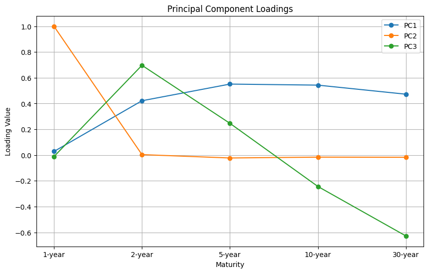

```python
from sklearn.decomposition import PCA
import matplotlib.pyplot as plt

# Perform PCA on yield changes
pca = PCA()
principal_components = pca.fit_transform(yield_changes)

# Create results table
results = pd.DataFrame({
    'Eigenvalues': pca.explained_variance_,
    'Variance Explained': pca.explained_variance_ratio_,
    'Cumulative Variance': pca.explained_variance_ratio_.cumsum()
})

# Standard deviations of factor scores
factor_stdev = np.std(principal_components, axis=0, ddof=1)

print("PCA Results Table:")
display(results)
print("\nFactor Score Standard Deviations:")
display(pd.Series(factor_stdev, index=[f'PC{i+1}' for i in range(5)]))

# Plot loadings for first three components
plt.figure(figsize=(10, 6))
for i in range(3):
    plt.plot(maturities, pca.components_[i], marker='o', label=f'PC{i+1}')

plt.title('Principal Component Loadings')
plt.xlabel('Maturity')
plt.ylabel('Loading Value')
plt.legend()
plt.grid(True)
plt.show()
```

## IV. Portfolio VaR Calculation

```python
# Portfolio sensitivities (Table 1)
dv01 = pd.Series({
    '1-year': 15,
    '2-year': 3,
    '5-year': -4,
    '10-year': -11,
    '30-year': 1
}, index=fred_codes) * 1e4  # Convert million dollars to dollars

# Project sensitivities onto first three PCs
pc_sensitivities = np.dot(dv01.values, pca.components_[:3].T)

# Portfolio volatility from first three factors
portfolio_vol = np.sqrt(np.sum((pc_sensitivities * factor_stdev[:3])**2))

# Calculate 1-day 99% VaR
var_99 = portfolio_vol * 2.33  # Z-score for 99% confidence

print(f"Portfolio 1-day 99% VaR: ${var_99/1e6:.2f} million")
```

```
Portfolio 1-day 99% VaR: $nan million
```

# P3) Liquidity Risk

## I. *Select*

```python
!pip install finpy-tse -q
```

```
  Preparing metadata (setup.py) ... done
     ━━━━━━━━━━━━━━━━━━━━━━━━━━━━━━━━━━━━━━━━ 44.4/44.4 kB 2.5 MB/s eta 0:00:00
   ━━━━━━━━━━━━━━━━━━━━━━━━━━━━━━━━━━━━━━━━ 101.8/101.8 kB 4.7 MB/s eta 0:00:00
   ━━━━━━━━━━━━━━━━━━━━━━━━━━━━━━━━━━━━━━━━ 52.6/52.6 kB 3.4 MB/s eta 0:00:00
   ━━━━━━━━━━━━━━━━━━━━━━━━━━━━━━━━━━━━━━━━ 172.3/172.3 kB 9.7 MB/s eta 0:00:00
   ━━━━━━━━━━━━━━━━━━━━━━━━━━━━━━━━━━━━━━━━ 1.6/1.6 MB 32.0 MB/s eta 0:00:00
   ━━━━━━━━━━━━━━━━━━━━━━━━━━━━━━━━━━━━━━━━ 259.8/259.8 kB 15.6 MB/s eta 0:00:00
```

```python
#from finpy_tse import Get_IntradayOB_History
import finpy_tse as fpy
fpy.Get_Price_History(
    stock='خودرو',
    start_date='1400-02-01',
    end_date='1400-02-02',
    ignore_date=False,
    adjust_price=False,
    show_weekday=False,
    double_date=False)


print(raw_data.type())
```

[output not shown]

[output cut: 96 more lines]

[output not shown]

# P4) Monte-Carlo in Credit Risk

## I. *Generate* Synthetic Company Data

```python
import numpy as np
import pandas as pd

# Part I: Generate synthetic data for 10 companies
np.random.seed(42)
num_companies = 10

# Generate parameters
V = np.random.uniform(500, 4000, num_companies)  # Asset values in billions
D = np.random.uniform(300, 3800, num_companies)  # Debt values (D < V)
D = np.minimum(D, V * 0.95)  # Ensure D < V
sigma_v = np.random.uniform(0.15, 0.40, num_companies)  # Annualized asset volatility
r = 0.10  # Risk-free rate
T = 1.0   # Time to maturity

companies = pd.DataFrame({
    'Company': [f'Co{i+1}' for i in range(num_companies)],
    'V': V,
    'D': D,
    'sigma_v': sigma_v
})
print("Generated Companies Data:")
print(companies)
```

```
Generated Companies Data:
  Company            V            D   sigma_v
0     Co1  1810.890416   372.045730  0.302963
1     Co2  3827.500072  3636.125069  0.184873
2     Co3  3061.978796  2908.879857  0.223036
3     Co4  2595.304695  1043.186887  0.241590
4     Co5  1046.065242   936.387385  0.264017
5     Co6  1045.980821   941.915784  0.346294
6     Co7   703.292643   668.128010  0.199918
7     Co8  3531.616510  2136.647511  0.278559
8     Co9  2603.902541  1811.807565  0.298104
9    Co10  2978.254022  1319.301991  0.161613
```

## II. *Distance to difault* and *probability if default*

```python
from scipy.stats import norm
import numpy as np

# Corrected Merton model functions
def distance_to_default(V, D, sigma_V, r, T):
    return (np.log(V / D) + (r - 0.5 * sigma_V**2) * T) / (sigma_V * np.sqrt(T))

def probability_of_default(V, D, sigma_V, r, T):
    dd = distance_to_default(V, D, sigma_V, r, T)
    return norm.cdf(-dd)
# Parameters
r = 0.10  # Risk-free rate
T = 1.0   # Time to maturity (1 year)

# Calculate DD and PD for each company
companies['DD'] = distance_to_default(companies['V'], companies['D'], companies['sigma_v'], r, T)
companies['PD'] = probability_of_default(companies['V'], companies['D'], companies['sigma_v'], r, T)

print("\nCompanies with Distance to Default and Probability of Default:")
#print(companies[['Company', 'V', 'D', 'sigma_v', 'DD', 'PD']])
companies
```

```
Companies with Distance to Default and Probability of Default:
```

|  | Company | V | D | sigma_v | DD | PD |
| --- | --- | --- | --- | --- | --- | --- |
| 0 | Co1 | 1810.890416 | 372.045730 | 0.302963 | 5.402186 | 3.291674e-08 |
| 1 | Co2 | 3827.500072 | 3636.125069 | 0.184873 | 0.725925 | 2.339425e-01 |
| 2 | Co3 | 3061.978796 | 2908.879857 | 0.223036 | 0.566817 | 2.854192e-01 |
| 3 | Co4 | 2595.304695 | 1043.186887 | 0.241590 | 4.065726 | 2.394159e-05 |
| 4 | Co5 | 1046.065242 | 936.387385 | 0.264017 | 0.666278 | 2.526166e-01 |
| 5 | Co6 | 1045.980821 | 941.915784 | 0.346294 | 0.418242 | 3.378851e-01 |
| 6 | Co7 | 703.292643 | 668.128010 | 0.199918 | 0.656816 | 2.556497e-01 |
| 7 | Co8 | 3531.616510 | 2136.647511 | 0.278559 | 2.023704 | 2.150030e-02 |
| 8 | Co9 | 2603.902541 | 1811.807565 | 0.298104 | 1.403047 | 8.030142e-02 |
| 9 | Co10 | 2978.254022 | 1319.301991 | 0.161613 | 5.576144 | 1.229544e-08 |

## III. Analyze Risk and PD Influences

### III.I. PD vs. volatility and leverage

ابتدا در زیر نحوه تغییر PD با تلاطم و اهرم را بررسی می‌کنم. مشاهده می‌شود که به ازای مقداراهرم تا کمتر از حدود ۵۰ درصد با تغییر تلاطم در گستره فرض شده در سوال احتمال نکول تقریباً ناچیز است. با افزایش اهرم حتی به ازای تلاطم کوچک احتمال نکول به سرعت افزایش می‌یابد.

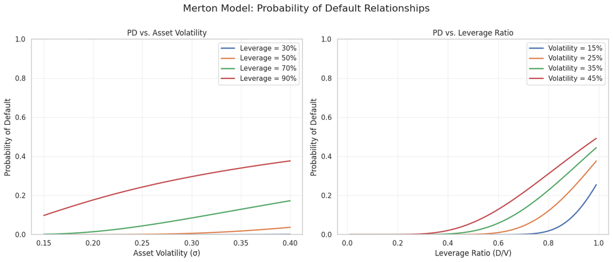

```python
import numpy as np
import matplotlib.pyplot as plt
from scipy.stats import norm

# Parameters
r = 0.10  # Risk-free rate (10%)
T = 1.0   # Time to maturity (1 year)
V = 1000  # Fixed asset value (arbitrary, since PD depends on D/V ratio)

# Create figure with 2 subplots
fig, (ax1, ax2) = plt.subplots(1, 2, figsize=(14, 6))
fig.suptitle("Merton Model: Probability of Default Relationships", fontsize=16)

# Plot 1: PD vs. Volatility (fixed leverage)
leverage_ratios = [0.3, 0.5, 0.7, 0.9]  # D/V ratios
volatilities = np.linspace(0.15, 0.4, 100)  # 5% to 80% volatility

for lev in leverage_ratios:
    D = lev * V  # Debt value
    pds = [probability_of_default(V, D, sigma, r, T) for sigma in volatilities]
    ax1.plot(volatilities, pds, lw=2, label=f'Leverage = {lev:.0%}')

ax1.set_title('PD vs. Asset Volatility')
ax1.set_xlabel('Asset Volatility (σ)')
ax1.set_ylabel('Probability of Default')
ax1.grid(True, alpha=0.3)
ax1.legend()
ax1.set_ylim(0, 1)

# Plot 2: PD vs. Leverage (fixed volatility)
volatility_levels = [0.15, 0.25, 0.35, 0.45]  # 15% to 45% volatility
leverages = np.linspace(0.01, 0.99, 100)  # 1% to 99% leverage

for vol in volatility_levels:
    pds = [probability_of_default(V, lev*V, vol, r, T) for lev in leverages]
    ax2.plot(leverages, pds, lw=2, label=f'Volatility = {vol:.0%}')

ax2.set_title('PD vs. Leverage Ratio')
ax2.set_xlabel('Leverage Ratio (D/V)')
ax2.set_ylabel('Probability of Default')
ax2.grid(True, alpha=0.3)
ax2.legend()
ax2.set_ylim(0, 1)

plt.tight_layout()
plt.subplots_adjust(top=0.85)
plt.show()
```

### III.II. Trends in dataset

در مرحله بعد همه شرکت‌ها را در یک صفحه تلاطم-اهرم نمایش می‌دهم و احتمال نکول هر کدام را کنار آن قرار می‌دهم. در هماهنگی را مشاهده‌های بخش ابتدایی برای نمونه‌هایی که اهرم آنها از آستانه ۵۰٪ کمتر است در یک گستره نسبتاً بزرگ تلاطم احتمال نکول پایین است. برای نمونه‌هایی که اهرم آنها بالاتر از این آستانه است احتمال نکول حتی در تلاطم کوچک چند برابر بزرگ‌‌تر است.

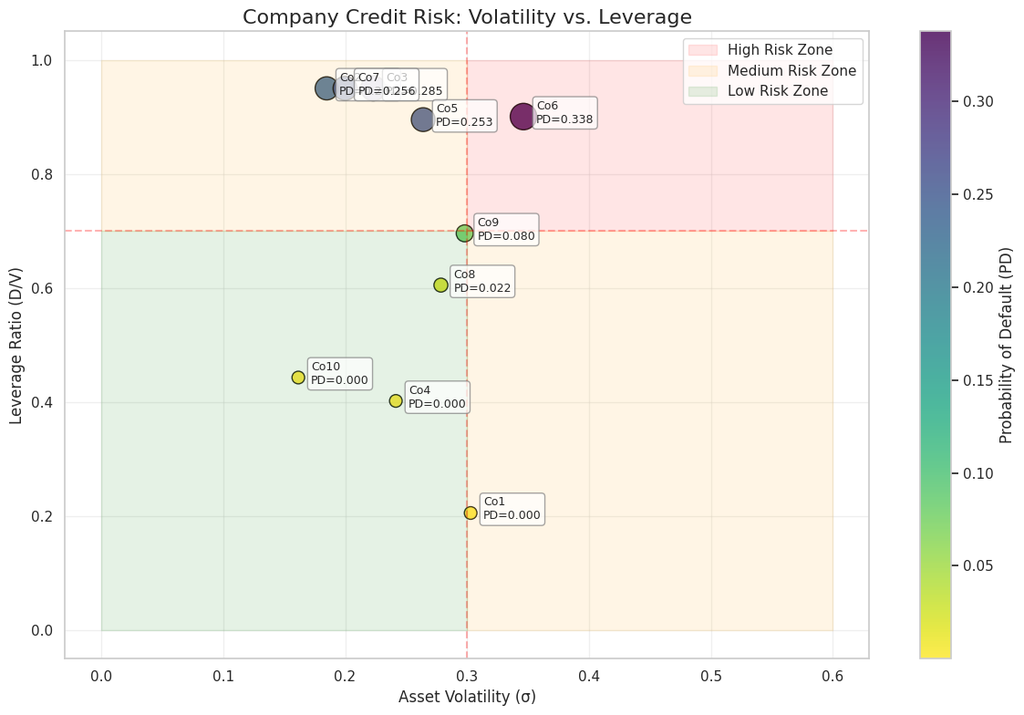

```
Companies Data with Risk Metrics:
  Company            V            D   sigma_v  Leverage            PD
0     Co1  1810.890416   372.045730  0.302963  0.205449  3.291674e-08
1     Co2  3827.500072  3636.125069  0.184873  0.950000  2.339425e-01
2     Co3  3061.978796  2908.879857  0.223036  0.950000  2.854192e-01
3     Co4  2595.304695  1043.186887  0.241590  0.401952  2.394159e-05
4     Co5  1046.065242   936.387385  0.264017  0.895152  2.526166e-01
5     Co6  1045.980821   941.915784  0.346294  0.900510  3.378851e-01
6     Co7   703.292643   668.128010  0.199918  0.950000  2.556497e-01
7     Co8  3531.616510  2136.647511  0.278559  0.605006  2.150030e-02
8     Co9  2603.902541  1811.807565  0.298104  0.695805  8.030142e-02
9    Co10  2978.254022  1319.301991  0.161613  0.442978  1.229544e-08
```

```python
import matplotlib.pyplot as plt
import numpy as np

# Assuming 'companies' DataFrame exists from previous steps
# Calculate leverage ratio (D/V)
companies['Leverage'] = companies['D'] / companies['V']

# Create scatter plot
plt.figure(figsize=(12, 8))
plt.grid(True, alpha=0.3)

# Plot each company with PD as size and color
scatter = plt.scatter(
    companies['sigma_v'],
    companies['Leverage'],
    s=companies['PD']*1000 + 100,  # Size proportional to PD
    c=companies['PD'],             # Color proportional to PD
    cmap='viridis_r',
    alpha=0.8,
    edgecolors='black'
)

# Add colorbar
cbar = plt.colorbar(scatter)
cbar.set_label('Probability of Default (PD)')

# Add labels and title
plt.title('Company Credit Risk: Volatility vs. Leverage', fontsize=16)
plt.xlabel('Asset Volatility (σ)', fontsize=12)
plt.ylabel('Leverage Ratio (D/V)', fontsize=12)

# Add company names and PD values as annotations
for i, row in companies.iterrows():
    plt.annotate(
        f"{row['Company']}\nPD={row['PD']:.3f}",
        (row['sigma_v'], row['Leverage']),
        xytext=(10, -5),
        textcoords='offset points',
        fontsize=9,
        bbox=dict(boxstyle="round,pad=0.3", fc="white", ec="gray", alpha=0.7)
    )

# Add risk level zones
plt.axhline(y=0.7, color='red', linestyle='--', alpha=0.3)
plt.axvline(x=0.3, color='red', linestyle='--', alpha=0.3)
plt.fill_between([0.3, 0.6], 0.7, 1.0, color='red', alpha=0.1, label='High Risk Zone')
plt.fill_between([0.0, 0.3], 0.7, 1.0, color='orange', alpha=0.1, label='Medium Risk Zone')
plt.fill_between([0.3, 0.6], 0.0, 0.7, color='orange', alpha=0.1)
plt.fill_between([0.0, 0.3], 0.0, 0.7, color='green', alpha=0.1, label='Low Risk Zone')

# Add legend and adjust layout
plt.legend(loc='upper right')
plt.tight_layout()
plt.show()

# Print the companies DataFrame for reference
print("\nCompanies Data with Risk Metrics:")
print(companies[['Company', 'V', 'D', 'sigma_v', 'Leverage', 'PD']])
```

## IV. Assign credit ratings

### IV.I. Using *equal intervals*

این سوال به نظر می‌رسد خواسته‌های ناهمساز دارد. رتبه‌بندی مانند آزانس رتبه‌بندی و رتبه‌بندی با فاصله‌های مساوی نتیجه‌های مختلفی به دست می‌دهد. برای مثال در بخش اول رتبه‌بندی با فاصله‌های مساوی انجام شده است. این کار باعث می‌شود شرکت‌ها به دو دسته A و C تقسیم شوند و رتبه B به شرکتی تعلق نمی‌گیرد.

مسأله قابل تأمل این است که چرا نمونه‌ای بااحتمال نکول در بازه ۱۰٪ تا ۲۰٪ قرار نگرفت (البته ممکن است این همان موضوع مورد سوال در قسمت پیش بوده باشد و خواسته قسمت پیش را دقیق متجه نشده باشم؛ چون توضیح این اتفاق باز هم به رفتار احتمال نکول باز می‌گردد.) در قسمت بعد به این موضوع پرداختم.

```python
companies_sorted = companies.sort_values('PD')
bins = np.linspace(companies_sorted['PD'].min(), companies_sorted['PD'].max(), 4)
labels = ['A', 'B', 'C']
companies_sorted['Rating'] = pd.cut(companies_sorted['PD'], bins=bins, labels=labels, include_lowest=True)

print("\nCompanies Sorted by PD with Ratings:")
print(companies_sorted[['Company', 'Rating']].assign(
    PD_pct = companies['PD'].apply(lambda x: f"{x:.4%}")
).rename(columns={'PD_pct': 'PD (%)'}))
```

```
Companies Sorted by PD with Ratings:
  Company Rating    PD (%)
9    Co10      A   0.0000%
0     Co1      A   0.0000%
3     Co4      A   0.0024%
7     Co8      A   2.1500%
8     Co9      A   8.0301%
1     Co2      C  23.3942%
4     Co5      C  25.2617%
6     Co7      C  25.5650%
2     Co3      C  28.5419%
5     Co6      C  33.7885%
```

### IV.II. Distribution of PD

با مشاهده توزیع احتمال نکول و دونمایی بودن آن می‌توان به علت اینکه نمونه‌ای در بازه ۱۰٪ تا ۲۰٪ قرار نگرفته پی برد.

[figure not shown]

```python
import numpy as np
import pandas as pd
import matplotlib.pyplot as plt
import seaborn as sns
from scipy.stats import norm

# Set aesthetics
sns.set_theme(style="whitegrid")
plt.figure(figsize=(12, 8))

# Generate large sample for clear distribution
np.random.seed(42)
n = 5000  # Larger sample for smooth distribution
V = np.random.uniform(500, 4000, n)
D = np.random.uniform(300, 3800, n)
D = np.minimum(D, V * 0.95)  # Ensure D < V
σ = np.random.uniform(0.15, 0.40, n)
r = 0.10
T = 1.0

# Merton model functions
def distance_to_default(V, D, σ, r, T):
    return (np.log(V/D) + (r - 0.5*σ**2)*T) / (σ*np.sqrt(T))

def probability_of_default(V, D, σ, r, T):
    dd = distance_to_default(V, D, σ, r, T)
    return norm.cdf(-dd)

# Calculate PDs
pds = probability_of_default(V, D, σ, r, T)

# Create histogram with KDE
ax = sns.histplot(pds, bins=50, kde=True, stat='density',
                 color='skyblue', edgecolor='navy',
                 linewidth=0.5, alpha=0.7)

# Highlight sparse region
plt.axvspan(0.10, 0.20, color='yellow', alpha=0.3,
            label='Sparse Region (10-20% PD)')

# Add KDE line
sns.kdeplot(pds, color='darkred', linewidth=2)

# Annotate modes
plt.annotate('Safe Companies\n(0-5% PD)', xy=(0.03, 8), xytext=(0.01, 10),
             arrowprops=dict(facecolor='black', shrink=0.05, width=1.5),
             fontsize=12, bbox=dict(boxstyle="round,pad=0.3", fc="white", ec="gray", alpha=0.8))

plt.annotate('Distressed Companies\n(25-60% PD)', xy=(0.35, 3), xytext=(0.25, 5),
             arrowprops=dict(facecolor='black', shrink=0.05, width=1.5),
             fontsize=12, bbox=dict(boxstyle="round,pad=0.3", fc="white", ec="gray", alpha=0.8))

# Formatting
plt.title('Bimodal Distribution of Probability of Default\n(Merton Model)', fontsize=16)
plt.xlabel('Probability of Default', fontsize=14)
plt.ylabel('Density', fontsize=14)
plt.legend(fontsize=12)
plt.grid(True, alpha=0.3)
plt.xlim(0, 0.8)

# Add statistics box
stats_text = f"""
Distribution Statistics:
- Sample size: {n:,}
- Mean PD: {np.mean(pds):.3f}
- Min PD: {np.min(pds):.6f}
- Max PD: {np.max(pds):.3f}
- Companies in 10-20% range: {np.sum((pds >= 0.10) & (pds <= 0.20)):,} ({np.mean((pds >= 0.10) & (pds <= 0.20)):.1%})
"""
plt.text(0.62, 8, stats_text, fontsize=12,
         bbox=dict(boxstyle="round,pad=0.4", fc="white", ec="gray", alpha=0.8))

plt.tight_layout()
plt.show()
```

### IV.III. Rating *like a rating agency*

در این بخش به جای استفاده از بازه‌های مساوی با الهام از ربته‌بندی S&P یک ربته‌بندی دیگر انجام دادم. در این حالت بعضی از شرکت‌ها ربته B می‌گیرند.

```python
import numpy as np
import pandas as pd
import matplotlib.pyplot as plt

# S&P PD to rating mapping (from provided table)
sp_ratings = {
    'ruAAA': 0.003626, 'ruAA+': 0.004885, 'ruAA': 0.006579, 'ruAA-': 0.008855,
    'ruA+': 0.011909, 'ruA': 0.015999, 'ruA-': 0.021464, 'ruBBB+': 0.028741,
    'ruBBB': 0.038388, 'ruBBB-': 0.051103, 'ruBB+': 0.067732, 'ruBB': 0.089263,
    'ruBB-': 0.111503, 'ruB+': 0.151375, 'ruB': 0.193964, 'ruB-': 0.245074,
    'ruCCC+': 0.304565, 'ruCCC': 0.371391, 'ruCCC-': 0.443529, 'ruCC': 0.51813,
    'ruC': 0.591931, 'ruD': 0.661806
}

# Create rating categories based on S&P conventions
rating_bins = [
    ('A', 0, 0.021464),      # ruAAA to ruA- (Investment Grade)
    ('B', 0.021465, 0.089263), # ruBBB+ to ruBB (Lower Grade)
    ('C', 0.089264, 1.0)      # ruBB- to ruD (Speculative)
]

# Function to assign rating based on PD
def assign_rating(pd_value):
    for rating, min_pd, max_pd in rating_bins:
        if min_pd <= pd_value <= max_pd:
            return rating
    return 'C'  # Default to speculative if not in range

# Apply S&P-based rating to companies
companies['SP_Rating'] = companies['PD'].apply(assign_rating)

# Print final rating assignments
print("Companies with S&P-Based Ratings:")
print(companies[['Company', 'PD', 'SP_Rating']])
```

```
Companies with S&P-Based Ratings:
  Company            PD SP_Rating
0     Co1  3.291674e-08         A
1     Co2  2.339425e-01         C
2     Co3  2.854192e-01         C
3     Co4  2.394159e-05         A
4     Co5  2.526166e-01         C
5     Co6  3.378851e-01         C
6     Co7  2.556497e-01         C
7     Co8  2.150030e-02         B
8     Co9  8.030142e-02         B
9    Co10  1.229544e-08         A
```

## V. **Pick** 4 companies

متأسفانه متوجه نشدم که چهار شرکت با رتبه‌بندی مختلف باید انتخاب کرد یا سه شرکت؛ چون سه رتبه بیشتر نداریم.

```python
selected_companies = companies.groupby('SP_Rating').sample(1, random_state=42)
print("\nSelected Companies with Different Ratings:")
print(selected_companies[['Company', 'PD', 'SP_Rating']])
```

```
Selected Companies with Different Ratings:
  Company            PD SP_Rating
0     Co1  3.291674e-08         A
8     Co9  8.030142e-02         B
2     Co3  2.854192e-01         C
```

## VI. Bond Portfolio Simulation Function

### VI.I. Synthetizing portfolio and tables

```python
# Bond Portfolio (Table 2)
bonds = pd.DataFrame({
    'Bond ID': ['B1', 'B2', 'B3', 'B4', 'B5', 'B6', 'B7', 'B8', 'B9', 'B10'],
    'Issuer': ['CoAlpha', 'CoBeta', 'CoGamma', 'CoDelta', 'CoEpsilon',
               'CoZeta', 'CoEta', 'CoTheta', 'Colota', 'CoKappa'],
    'Rating': ['A', 'B', 'C', 'B', 'A', 'C', 'B', 'D', 'A', 'C'],
    'Seniority': ['Senior', 'Subordinated', 'Junior', 'Senior', 'Subordinated',
                  'Junior', 'Junior', 'Junior', 'Senior', 'Subordinated'],
    'Maturity': [3, 2, 4, 5, 1, 3, 4, 2, 2, 5],
    'Face Value': [1000, 800, 1200, 1000, 1500, 900, 1100, 600, 700, 1300],
    'Coupon Rate': [0.106, 0.125, 0.168, 0.135, 0.105, 0.160, 0.140, 0.215, 0.103, 0.170]
})

# Zero Curve (Table 3)
zero_curve = {
    'A': [0.10, 0.103, 0.106, 0.108, 0.110],
    'B': [0.115, 0.120, 0.125, 0.130, 0.135],
    'C': [0.135, 0.142, 0.150, 0.158, 0.165]
}

# Transition Matrix (Table 4)
transition_matrix = {
    'A': {'A': 0.90, 'B': 0.08, 'C': 0.015, 'D': 0.005},
    'B': {'A': 0.04, 'B': 0.84, 'C': 0.07, 'D': 0.05},
    'C': {'A': 0.02, 'B': 0.10, 'C': 0.70, 'D': 0.18}
}

# Recovery Rates (Table 5)
recovery_params = {
    'Senior': {'mean': 0.60, 'std': 0.10},
    'Subordinated': {'mean': 0.40, 'std': 0.15},
    'Junior': {'mean': 0.25, 'std': 0.20}
}
```

### VI.II. Bond pricing and simulation functions

```python
# Last version

def bond_price(face_value, coupon_rate, maturity, rating, zero_curve):
    """Calculate bond price using zero curve"""
    price = 0
    coupon = coupon_rate * face_value
    for t in range(1, maturity + 1):
        rate = zero_curve[rating][t - 1]  # Zero rate for year t
        discount_factor = 1 / (1 + rate) ** t
        price += coupon * discount_factor
    price += face_value * discount_factor  # Principal repayment
    return price

def simulate_portfolio_loss(bonds, zero_curve, transition_matrix, recovery_params, n_sim=10000):
    np.random.seed(42)
    losses = []
    risk_free_rate = 0.10

    # Precompute initial prices
    initial_prices = {}
    for _, bond in bonds.iterrows():
        if bond['Rating'] == 'D':
            # For defaulted bonds: initial price = expected recovery
            rr_mean = recovery_params[bond['Seniority']]['mean']
            initial_prices[bond['Bond ID']] = bond['Face Value'] * rr_mean
        else:
            initial_prices[bond['Bond ID']] = bond_price(
                bond['Face Value'], bond['Coupon Rate'],
                bond['Maturity'], bond['Rating'], zero_curve
            )

    for _ in range(n_sim):
        total_loss = 0

        for _, bond in bonds.iterrows():
            bond_id = bond['Bond ID']
            price_t0 = initial_prices[bond_id]

            if bond['Rating'] == 'D':
                # Already defaulted: loss is fixed
                loss = 0  # Loss already accounted for at purchase
            else:
                # Simulate rating transition
                current_rating = bond['Rating']
                new_rating = np.random.choice(
                    list(transition_matrix[current_rating].keys()),
                    p=list(transition_matrix[current_rating].values())
                )

                if new_rating == 'D':
                    # Default scenario
                    rr_mean = recovery_params[bond['Seniority']]['mean']
                    rr_std = recovery_params[bond['Seniority']]['std']
                    recovery = max(0, min(np.random.normal(rr_mean, rr_std), 1.0))
                    recovery_value = bond['Face Value'] * recovery
                    # Loss = Face Value - Recovery Value
                    loss = bond['Face Value'] - recovery_value
                else:
                    # Non-default scenario
                    new_maturity = bond['Maturity'] - 1
                    if new_maturity <= 0:
                        # Bond matured
                        value_t1 = bond['Face Value'] + bond['Coupon Rate'] * bond['Face Value']
                    else:
                        value_t1 = bond_price(
                            bond['Face Value'], bond['Coupon Rate'],
                            new_maturity, new_rating, zero_curve
                        )
                    # Calculate MTM loss (price depreciation)
                    loss = price_t0 - value_t1

            total_loss += loss

        # Discount total loss to present value
        discounted_loss = total_loss / (1 + risk_free_rate)
        losses.append(discounted_loss)

    return np.array(losses)
```

## VII. Loss Distribution Analysis

مطابق خواسته سوال برای ۱۰۰۰۰ بار شبیه سازی انجام شد؛ ولی هیستوگرام با چیزی که توقع داشتم اختلاف جدی دارد که البته نتوانستم بفهمم درست هست یا نه. کد در بازبینی‌هایی که کردم در ظاهر ایرادی ندارد؛ اما هیستوگرام یک ضرر منفی با بسامد زیاد نشان می دهد. این ضررها که به علت احتمال بهبود رتبه احتمال مثبت دارند دور از تصور نبودند و هیستوگرام باید در مقدارهای منفی ضرر هم بسامد مثبت نشان می‌داد. مشکل در بسامد بالای این ضررهای منفی و یا در واقع سودهاست که نباید چندان بزرگ می‌شد ولی شده است.

به جز این مورد در بخش زیان مثبت شکل هیستوگرام مطابق انتظار و چوله به راست است.

```
Expected Loss: 262.16
99% VaR: 1850.91
99% Expected Shortfall: 2162.43
```

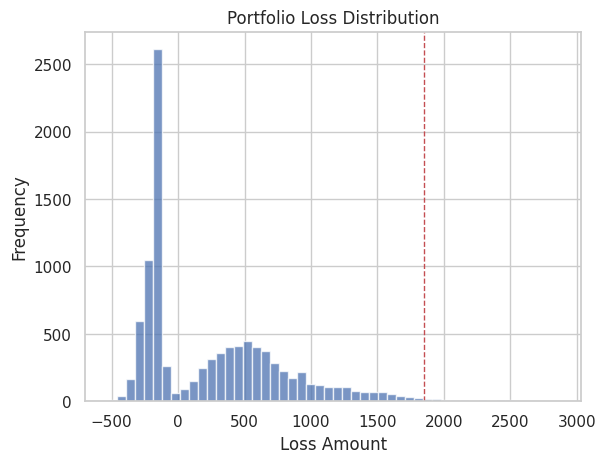

```python
# Run simulation
losses = simulate_portfolio_loss(bonds, zero_curve, transition_matrix, recovery_params)

# Calculate risk metrics
expected_loss = np.mean(losses)
var_99 = np.percentile(losses, 99)
es_99 = losses[losses >= var_99].mean()

print(f"Expected Loss: {expected_loss:.2f}")
print(f"99% VaR: {var_99:.2f}")
print(f"99% Expected Shortfall: {es_99:.2f}")

# Plot loss distribution
import matplotlib.pyplot as plt
plt.hist(losses, bins=50, alpha=0.75)
plt.axvline(var_99, color='r', linestyle='dashed', linewidth=1)
plt.title('Portfolio Loss Distribution')
plt.xlabel('Loss Amount')
plt.ylabel('Frequency')
plt.show()
```